```python
import pandas as pd

# Load dataset with correct encoding and delimiter
file_path = "D:/Georgetown/25spring_semester/DS2/final project/stage 1/Xu_Stage1.csv"
df = pd.read_csv(file_path, encoding="utf-16", delimiter="\t")

# 1. Clean column names by stripping whitespace
df.columns = df.columns.str.strip()

# 2. Handle missing values
df['Employer (Petitioner) Name'].fillna('Unknown', inplace=True)  # Fill missing employer names with 'Unknown'
df['Tax ID'].fillna(-1, inplace=True)  # Fill missing tax ID with -1
df['Industry (NAICS) Code'].fillna('Other', inplace=True)  # Fill missing industry codes with 'Other'
df['Petitioner City'].fillna('Unknown', inplace=True)  # Fill missing city names with 'Unknown'
df['Petitioner State'].fillna('Unknown', inplace=True)  # Fill missing state names with 'Unknown'
df['Petitioner Zip Code'].fillna(df['Petitioner Zip Code'].median(), inplace=True)  # Fill missing zip codes with median value

# 3. Convert numerical columns to integers after removing commas
num_cols = ['Initial Approval', 'Initial Denial', 'Continuing Approval', 'Continuing Denial']
df[num_cols] = df[num_cols].astype(str).replace(',', '', regex=True).astype(int)

# 4. Create new computed features
df["Total Approvals"] = df["Initial Approval"] + df["Continuing Approval"]
df["Total Denials"] = df["Initial Denial"] + df["Continuing Denial"]

df["Approval Rate"] = df["Total Approvals"] / (df["Total Approvals"] + df["Total Denials"] + 1e-6)
df["Denial Rate"] = df["Total Denials"] / (df["Total Approvals"] + df["Total Denials"] + 1e-6)

# 5. Ensure Fiscal Year is numeric
df["Fiscal Year"] = pd.to_numeric(df["Fiscal Year"], errors="coerce")

# 6. Save the cleaned dataset
processed_file_path = "Xu_Stage1_Cleaned.csv"
df.to_csv(processed_file_path, index=False, encoding="utf-16")
```

[output not shown]

### **Data Preprocessing Explanation**

In this dataset preprocessing process, several key steps were taken to ensure data integrity, consistency, and usability for analysis. Below is an overview of the preprocessing techniques applied:

#### **1. Cleaning Column Names**

- The column names were **stripped of leading and trailing spaces** to prevent issues with column referencing.

#### **2. Handling Missing Values**

- **Employer Name**: Missing values were replaced with `'Unknown'` to maintain consistency.
- **Tax ID**: Missing values were replaced with `-1` since tax ID is a crucial identifier but may not always be available.
- **Industry Code**: Missing values were filled with `'Other'` to categorize unclassified industries.
- **City and State**: Missing values were replaced with `'Unknown'` to maintain uniformity.
- **Zip Code**: Missing values were filled with the **median** zip code value to prevent outliers from distorting location-based analysis.

#### **3. Data Type Conversion**

- Certain numerical columns (`Initial Approval`, `Initial Denial`, `Continuing Approval`, `Continuing Denial`) contained **comma-separated values**, which were converted to integers after removing commas.

#### **4. Feature Engineering (Creating New Variables)**

- **Total Approvals**: Sum of `Initial Approval` and `Continuing Approval`.
- **Total Denials**: Sum of `Initial Denial` and `Continuing Denial`.
- **Approval Rate**: Calculated as: [ \frac{\text{Total Approvals}}{\text{Total Approvals} + \text{Total Denials} + 1e-6} ] A small constant (`1e-6`) was added to prevent division by zero.
- **Denial Rate**: Calculated similarly to the approval rate.

#### **5. Ensuring Numerical Data Types**

- The **Fiscal Year** column was converted to a numeric format to ensure proper aggregation and trend analysis.

#### **6. Saving the Cleaned Dataset**

```python
# 1. Descriptive statistics for numerical variables
num_summary = df.describe()
num_summary.to_csv("Numerical_Summary.csv")

# 2. Descriptive statistics for categorical variables
cat_summary = df[['Industry (NAICS) Code', 'Petitioner State']].nunique().to_frame(name="Unique Values")
cat_summary.to_csv("Categorical_Summary.csv")

# 3. H-1B Application Trends (Annual Statistics)
if "Fiscal Year" in df.columns:
    yearly_summary = df.groupby("Fiscal Year")[["Total Approvals", "Total Denials"]].sum().reset_index()
    yearly_summary.to_csv("Yearly_H1B_Summary.csv")

# 4. save all the files
result_files = ["Numerical_Summary.csv", "Categorical_Summary.csv"]
if "Fiscal Year" in df.columns:
    result_files.append("Yearly_H1B_Summary.csv")

result_files
```

```
['Numerical_Summary.csv', 'Categorical_Summary.csv', 'Yearly_H1B_Summary.csv']
```

### **Descriptive Analysis of the H-1B Dataset**

#### **1. Numerical Summary**

The dataset consists of **61,456 records** related to H-1B visa petitions. The key numerical statistics include:

- **Fiscal Year**: All data belongs to the year **2024**, indicating a single-year dataset.
- **Tax ID**: The Tax ID values range from **-1 to 9999**, with a mean of approximately **4901.04**. The presence of `-1` indicates missing or unreported values.
- **Petitioner Zip Code**: The median zip code value is **48,180**, with a wide range from **603 to 99,901**, indicating a diverse geographical distribution of employers.
- **H-1B Approvals and Denials**:
  - **Initial Approval**: Mean of **2.3**, with a maximum value of **2,471**, indicating that some employers receive significantly more approvals than others.
  - **Initial Denial**: Relatively low mean of **0.058**, but with a maximum of **87** denials.
  - **Continuing Approval**: Mean of **4.2**, but the maximum reaches **6,667**, showing that some employers have a large number of visa renewals.
  - **Continuing Denial**: Mean of **0.075**, with a max value of **179** denials.
- **Total Approvals**: Mean of **6.49**, with a maximum of **8,955**.
- **Total Denials**: Mean of **0.13**, with a maximum of **185**.
- **Approval Rate**: High overall, with a mean of **96.8%**, indicating that the majority of petitions are approved.
- **Denial Rate**: Correspondingly low, averaging around **3.15%**.

#### **2. Yearly H-1B Approval and Denial Trends**

- For **Fiscal Year 2024**, the dataset records **399,403 total approvals** and **8,230 total denials**.
- The low denial rate suggests that the majority of H-1B applications are successfully processed, with minimal rejection.

#### **3. Categorical Summary**

- **Industry Distribution**: There are **21 unique industry categories** based on the **NAICS (North American Industry Classification System) Code**.
- **State Distribution**: H-1B petitions were filed from **58 different states or territories**, indicating nationwide participation in the program.

### **Key Insights**

- The **high approval rate (~97%)** suggests a favorable environment for H-1B applications in 2024.
- Some **employers file an exceptionally high number of applications**, with approvals reaching nearly **9,000 per employer**.
- The **industry diversity is relatively limited**, with only **21 unique industry categories**.
- The **geographical spread** (58 states/territories) indicates that H-1B petitions are not concentrated in just a few states but are rather distributed across the U.S.

# Methodology

## 1. Key Variables

- **Dependent Variables**: Total Approvals, Approval Rate, Total Denials
- **Independent Variables**: Fiscal Year, Industry (NAICS Code), Petitioner State, Employer Name
- **Control Variables**: Tax ID, Petitioner Zip Code

## 2. Analytical Approach

### 2.1 Descriptive Analysis

Summarizing trends in H-1B petitions by industry, state, and year.

### 2.2 Regression Analysis

Using multiple linear regression to estimate approval rates: $$ Approval Rate = β_0 + β_1 (Industry) + β_2 (State) + β_3 (Year) + ε $$

### 2.3 Difference-in-Differences (DID) (If policy changes exist)

Assessing policy impact on approval rates.

## 3. Justification of Approach

Regression explains variable influence; DID captures policy effects.

## 4. Anticipated Challenges

- Multicollinearity
- Missing data
- Single-year limitation

## 5. Expected Outcomes

- Identifying high-approval industries and states
- Employer-level approval patterns
- Policy impact assessment

# **Stage 3**

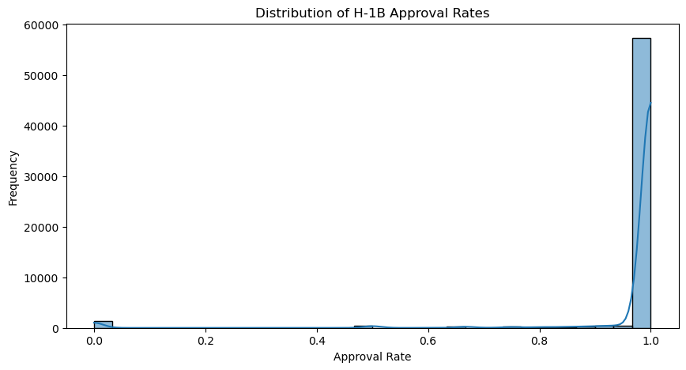

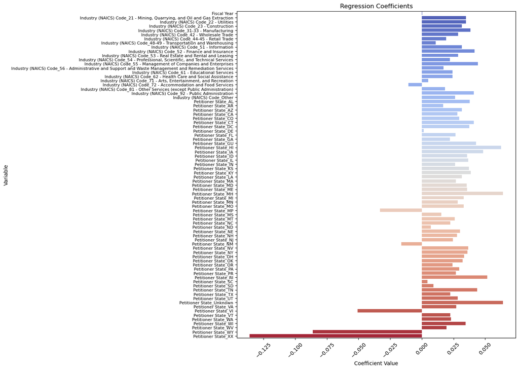

```
['Regression_Results.txt',
 'Approval_Rate_Distribution.png',
 'Regression_Coefficients.png',
 'Regression_Coefficients.csv']
```

```python
import pandas as pd
import statsmodels.api as sm
import matplotlib.pyplot as plt
import seaborn as sns

# Load the cleaned dataset
file_path = "Xu_Stage1_Cleaned.csv"
df = pd.read_csv(file_path, encoding="utf-16")

# Ensure column names are stripped of whitespace
df.columns = df.columns.str.strip()

# Define dependent and independent variables for regression
X = df[['Industry (NAICS) Code', 'Petitioner State', 'Fiscal Year']]
X = pd.get_dummies(X, drop_first=True)  # Convert categorical variables to dummy variables
y = df['Approval Rate']

# Convert X and y to numeric
X = X.apply(pd.to_numeric, errors='coerce')  # Ensure X is numeric
y = pd.to_numeric(y, errors='coerce')  # Ensure y is numeric

# Drop rows with NaN values after conversion
X = X.dropna()
y = y.loc[X.index]  # Ensure y matches X's index

# Convert boolean columns to int (0 or 1)
X = X.astype(int)

# Add constant for intercept
X = sm.add_constant(X)

# Run OLS regression model
model = sm.OLS(y, X).fit()

# Save regression results
regression_results = model.summary()
with open("Regression_Results.txt", "w") as f:
    f.write(str(regression_results))

# Visualizing the distribution of approval rates
plt.figure(figsize=(10, 5))
sns.histplot(df['Approval Rate'], bins=30, kde=True)
plt.title("Distribution of H-1B Approval Rates")
plt.xlabel("Approval Rate")
plt.ylabel("Frequency")
plt.savefig("Approval_Rate_Distribution.png")
plt.show()

# Visualizing regression coefficients
coef_df = pd.DataFrame({'Variable': X.columns, 'Coefficient': model.params.values})
plt.figure(figsize=(14, 10))  # Increase figure size
sns.barplot(x='Coefficient', y='Variable', data=coef_df, palette='coolwarm')
plt.title("Regression Coefficients")
plt.xlabel("Coefficient Value")
plt.ylabel("Variable")
plt.xticks(rotation=45)  # Rotate x-axis labels for better readability
plt.yticks(fontsize=8)  # Reduce y-axis label font size
plt.tight_layout()  # Adjust layout to prevent overlap
plt.savefig("Regression_Coefficients.png", dpi=300)
plt.show()

# Save data for further use
coef_df.to_csv("Regression_Coefficients.csv", index=False)

# Return generated files
result_files = ["Regression_Results.txt", "Approval_Rate_Distribution.png", "Regression_Coefficients.png", "Regression_Coefficients.csv"]
result_files
```

___Model Change___

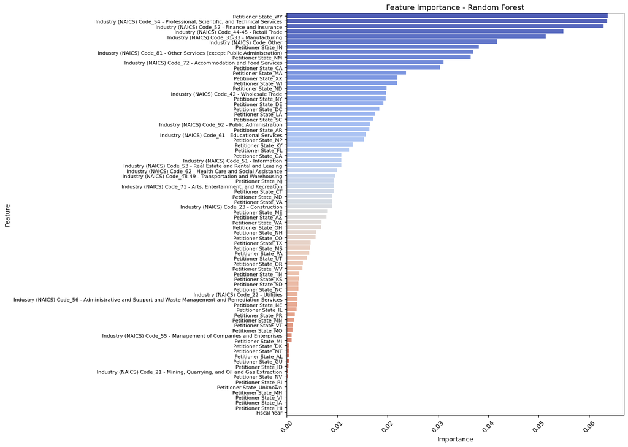

```
['RandomForest_Results.txt',
 'Feature_Importance.png',
 'Feature_Importance.csv']
```

```python
import numpy as np
from sklearn.model_selection import train_test_split
from sklearn.ensemble import RandomForestRegressor
from sklearn.metrics import r2_score, mean_absolute_error, mean_squared_error

# Load the cleaned dataset
file_path = "D:/Georgetown/25spring_semester/DS2/final project/stage2/Xu_Stage1_Cleaned.csv"
df = pd.read_csv(file_path, encoding="utf-16")

# Ensure column names are stripped of whitespace
df.columns = df.columns.str.strip()

# Define dependent and independent variables
X = df[['Industry (NAICS) Code', 'Petitioner State', 'Fiscal Year']]
X = pd.get_dummies(X, drop_first=True)  # Convert categorical variables to dummy variables
y = df['Approval Rate']

# Convert X and y to numeric
X = X.apply(pd.to_numeric, errors='coerce')  # Ensure X is numeric
y = pd.to_numeric(y, errors='coerce')  # Ensure y is numeric

# Drop rows with NaN values after conversion
X = X.dropna()
y = y.loc[X.index]  # Ensure y matches X's index

# Convert boolean columns to int (0 or 1)
X = X.astype(int)

# Split data into training and testing sets
X_train, X_test, y_train, y_test = train_test_split(X, y, test_size=0.2, random_state=42)

# Train a Random Forest model
rf_model = RandomForestRegressor(n_estimators=500, max_depth=10, random_state=42)
# rf_model = RandomForestRegressor(n_estimators=100, max_features='sqrt', random_state=42)
rf_model.fit(X_train, y_train)

# Predict on test set
y_pred = rf_model.predict(X_test)

# Evaluate model performance
r2 = r2_score(y_test, y_pred)
mae = mean_absolute_error(y_test, y_pred)
mse = mean_squared_error(y_test, y_pred)
rmse = np.sqrt(mse)

# Save evaluation metrics
metrics = f"R-squared: {r2}\nMAE: {mae}\nMSE: {mse}\nRMSE: {rmse}\n"
with open("RandomForest_Results.txt", "w") as f:
    f.write(metrics)

# Feature Importance Visualization
feature_importances = pd.DataFrame({'Feature': X.columns, 'Importance': rf_model.feature_importances_})
feature_importances = feature_importances.sort_values(by='Importance', ascending=False)

plt.figure(figsize=(14, 10))
sns.barplot(x='Importance', y='Feature', data=feature_importances, palette='coolwarm')
plt.title("Feature Importance - Random Forest")
plt.xlabel("Importance")
plt.ylabel("Feature")
plt.xticks(rotation=45)  # Rotate x-axis labels for better readability
plt.yticks(fontsize=8)  # Reduce y-axis label font size
plt.tight_layout()
plt.savefig("Feature_Importance.png", dpi=300)
plt.show()

# Save feature importance
feature_importances.to_csv("Feature_Importance.csv", index=False)

# Return generated files
result_files = ["RandomForest_Results.txt", "Feature_Importance.png", "Feature_Importance.csv"]
result_files
```